# Tugas Praktikum Pertemuan 3

Luthfia Aiman Hanin_G1401231064

## Eksplorasi Peubah

```r
# --- Load data ---
aqi <- rio::import("https://raw.githubusercontent.com/luthfiaaiman/mpdw/main/Pertemuan%203/NewDelhi_Air_quality.csv")

# --- Pilih variabel yang relevan ---
pollutants <- c("CO", "no2", "o3", "pm10", "pm25", "so2")

# --- Korelasi Pearson dengan AQI ---
cor_results <- sapply(pollutants, function(x) cor(aqi$AQI, aqi[[x]], method = "pearson"))
cor_results
```

```
##          CO         no2          o3        pm10        pm25         so2
##  0.79763320  0.73765472  0.97359901  0.08257568 -0.34665524 -0.74247813
```

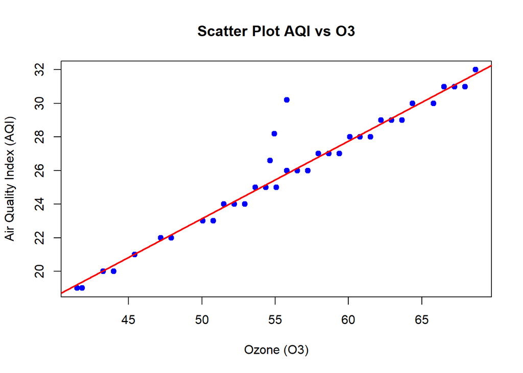

```r
# --- Scatter plot AQI vs O3 ---
plot(aqi$o3, aqi$AQI,
     main = "Scatter Plot AQI vs O3",
     xlab = "Ozone (O3)",
     ylab = "Air Quality Index (AQI)",
     pch = 19, col = "blue")
abline(lm(AQI ~ o3, data = aqi), col = "red", lwd = 2)
```

Hasil korelasi pearson antara Air Quality Index dengan setiap polutan menunjukkan bahwa polutan O3 memberikan nilai tertinggi yakni 0.97. Korelasinya yang sangat tinggi dibandingkan dengan polutan lain menjadi alasan dipilihnya peubah O3 untuk regresi time series berikutnya.

## *Packages*

```r
library(dLagM)
library(dynlm)
library(MLmetrics)
library(lmtest)
library(car)
```

## Impor Data

```r
aqi
```

```
##    V1  AQI       CO      datetime        no2       o3      pm10     pm25
## 1   0 30.2 198.6027 2022-10-21:18 0.04685717 55.78995 10.486722 5.637410
## 2   1 28.2 197.6013 2022-10-21:19 0.04645554 54.93164 10.719325 4.618169
## 3   2 26.6 198.6027 2022-10-21:20 0.04685717 54.64554 11.155578 3.520902
## 4   3 25.0 201.9405 2022-10-21:21 0.04819594 55.07469 11.116206 2.225919
## 5   4 26.0 205.2784 2022-10-21:22 0.04886533 55.78995 10.405250 1.979471
## 6   5 26.0 208.6163 2022-10-21:23 0.05020411 56.50520  9.402518 1.792677
## 7   6 26.0 208.6163 2022-10-22:00 0.05020411 55.78995  8.482822 1.752237
## 8   7 24.0 205.2784 2022-10-22:01 0.05020411 52.92892  7.586667 1.858459
## 9   8 23.0 200.2716 2022-10-22:02 0.04685717 50.06790  7.636587 2.208076
## 10  9 24.0 196.9338 2022-10-22:03 0.04417961 51.49841  8.487648 2.476681
## 11 10 25.0 198.6027 2022-10-22:04 0.04284084 53.64418  9.357371 2.585729
## 12 11 26.0 200.2716 2022-10-22:05 0.04049798 55.78995 10.338728 2.390081
## 13 12 27.0 203.6095 2022-10-22:06 0.04016329 59.36623 10.523314 2.086022
## 14 13 29.0 205.2784 2022-10-22:07 0.03882451 62.22725 10.635970 1.937047
```

[output cut: 131 more lines]

## Pembagian Data

```r
#SPLIT DATA
# Ambil hanya kolom AQI dan o3
aqi_sub <- aqi[, c("AQI", "o3")]

# Split data train & test (58 train, 14 test)
train <- aqi_sub[1:58, ]
test  <- aqi_sub[59:72, ]

# Ubah ke time series
train_ts <- ts(as.matrix(train), start = 1, frequency = 1)
test_ts  <- ts(as.matrix(test), start = 59, frequency = 1)
data.ts <- ts(as.matrix(aqi[, c("AQI", "o3")]), start = 1, frequency = 1)
```

## Model Koyck

**Formula Umum:**

$$y_t=a(1-\lambda)+\beta_0X_t+\beta_1Z_t+\lambda Y_{t-1}+V_t$$

dengan
$$V_t=u_t-\lambda
u_{t-1}$$

Di mana $\lambda$ (koefisien dari $Y_{t−1}$) menunjukkan “tingkat peluruhan” atau seberapa cepat pengaruh masa lalu memudar.

### Pemodelan

```r
#MODEL KOYCK
model.koyck <- koyckDlm(x = train$o3, y = train$AQI)
summary(model.koyck)
```

```
##
## Call:
## "Y ~ (Intercept) + Y.1 + X.t"
##
## Residuals:
##       Min        1Q    Median        3Q       Max
## -1.112282 -0.366467 -0.002877  0.258311  1.106529
##
## Coefficients:
##             Estimate Std. Error t value Pr(>|t|)
## (Intercept)  0.26260    0.93950   0.280    0.781
## Y.1          0.42943    0.08641   4.969 7.14e-06 ***
## X.t          0.25823    0.04259   6.064 1.35e-07 ***
## ---
## Signif. codes:  0 '***' 0.001 '**' 0.01 '*' 0.05 '.' 0.1 ' ' 1
##
## Residual standard error: 0.5239 on 54 degrees of freedom
## Multiple R-Squared: 0.9449,  Adjusted R-squared: 0.9429
## Wald test: 417.1 on 2 and 54 DF,  p-value: < 2.2e-16
##
## Diagnostic tests:
## NULL
##
##                             alpha      beta       phi
## Geometric coefficients:  0.460243 0.2582336 0.4294305
```

```r
AIC(model.koyck)
```

```
## [1] 92.98106
```

```r
BIC(model.koyck)
```

```
## [1] 101.1533
```

**Interpretasi Hasil:**

- Dari `summary`, kita dapatkan model:

  $$\hat{Y_t}=0.26260+0.25823X_t+0.42943Y_{t-1}$$

  Koefisien $X_t$ (0.25823) signifikan, artinya nilai $X$ saat ini berpengaruh terhadap $Y$.
- Koefisien $Y_{t−1}$ (0.42943) juga signifikan. Ini adalah **estimasi untuk** $\lambda$. Nilai ini menunjukkan bahwa sekitar 43% dari efek di periode sebelumnya masih “terbawa” ke periode saat ini.
- Adj R-Squared bernilai 0.9429 yang menunjukkan bahwa model mampu menjelaskan sekitar 94% variasi $Y$.

### Peramalan dan Akurasi

Berikut adalah hasil peramalan y untuk 5 periode kedepan menggunakan model koyck

```r
fore.koyck <- forecast(model = model.koyck, x=test$o3, h=5)
fore.koyck
```

```
## $forecasts
## [1] 22.51461 21.65971 20.92318 20.05278 19.58666
##
## $call
## forecast.koyckDlm(model = model.koyck, x = test$o3, h = 5)
##
## attr(,"class")
## [1] "forecast.koyckDlm" "dLagM"
```

```r
mape.koyck <- MAPE(fore.koyck$forecasts, test$AQI[1:5])
mape.koyck #data test
```

```
## [1] 0.03745022
```

```r
#akurasi data training
GoF(model.koyck)
```

```
##              n     MAE           MPE       MAPE      sMAPE      MASE      MSE
## model.koyck 57 0.39765 -0.0005611615 0.01494044 0.01491151 0.5986129 0.260024
##                  MRAE    GMRAE
## model.koyck 545222624 5097.033
```

Nilai MAPE terhadap data uji < 10% yakni 3,7% menunjukkan bahwa tingkat kesalahan prediksi sangat kecil dan model memiliki akurasi tinggi dalam meramalkan data baru. Dan MAPE pada data latihan sangat baik, menunjukkan error relatif rata-rata hanya 1.5%.

## Regression with Distributed Lag

### Pemodelan (Lag=3)

```r
model.dlm <- dlm(x = train$o3,y = train$AQI , q = 3)
summary(model.dlm)
```

```
##
## Call:
## lm(formula = model.formula, data = design)
##
## Residuals:
##      Min       1Q   Median       3Q      Max
## -0.46771 -0.30217  0.00862  0.28459  0.37206
##
## Coefficients:
##             Estimate Std. Error t value Pr(>|t|)
## (Intercept) -0.55029    0.59970  -0.918    0.363
## x.t          0.47549    0.04500  10.568 2.43e-14 ***
## x.1          0.03845    0.09981   0.385    0.702
## x.2         -0.07281    0.10132  -0.719    0.476
## x.3          0.02903    0.04755   0.611    0.544
## ---
## Signif. codes:  0 '***' 0.001 '**' 0.01 '*' 0.05 '.' 0.1 ' ' 1
##
## Residual standard error: 0.2911 on 50 degrees of freedom
## Multiple R-squared:  0.9842, Adjusted R-squared:  0.9829
## F-statistic: 777.2 on 4 and 50 DF,  p-value: < 2.2e-16
##
## AIC and BIC values for the model:
##        AIC      BIC
## 1 27.10177 39.14577
```

```r
AIC(model.dlm)
```

```
## [1] 27.10177
```

```r
BIC(model.dlm)
```

```
## [1] 39.14577
```

Dari hasil diatas, didapat bahwa $P-value$ dari $x_t<0.05$. Hal ini menunjukkan bahwa $x_t$ berpengaruh signifikan terhadap $y$. Adapun model keseluruhan yang terbentuk adalah sebagai berikut

$$\hat{Y_t}=-0.55029+0.47549X_t+0.03845X_{t-1}-0.07281X_{t-2}+0.02903X_{t-3}$$

### Peramalan dan Akurasi

Berikut merupakan hasil peramalan $y$ untuk 5 periode kedepan

```r
fore.dlm <- forecast(model = model.dlm, x=test$o3, h=5)
fore.dlm
```

```
## $forecasts
## [1] 21.89234 20.76931 20.09733 19.12124 18.90016
##
## $call
## forecast.dlm(model = model.dlm, x = test$o3, h = 5)
##
## attr(,"class")
## [1] "forecast.dlm" "dLagM"
```

```r
mape.dlm <- MAPE(fore.dlm$forecasts, test$AQI[1:5])
mape.dlm
```

```
## [1] 0.006476319
```

```r
#akurasi data training
GoF(model.dlm)
```

```
##            n       MAE           MPE        MAPE       sMAPE      MASE
## model.dlm 55 0.2412266 -9.770146e-05 0.008946519 0.008940958 0.3831246
##                 MSE      MRAE   GMRAE
## model.dlm 0.0770501 986225471 5879.35
```

Nilai MAPE terhadap data uji lebih kecil dari model koyck, yakni 0,65% menunjukkan bahwa tingkat kesalahan prediksi sangat kecil dan model memiliki akurasi yang sangat tinggi dalam meramalkan data baru. Dan MAPE pada data latihan sangat baik, menunjukkan error relatif rata-rata hanya 0,89%.

### *Lag* Optimum

```r
#penentuan lag optimum
finiteDLMauto(formula = AQI ~ o3,
              data = data.frame(train), q.min = 1, q.max = 10,
              model.type = "dlm", error.type = "AIC", trace = TRUE)
```

```
##    q - k    MASE      AIC      BIC     GMRAE   MBRAE R.Adj.Sq  Ljung-Box
## 10    10 0.33647 24.10757 48.43318 10779.390 0.48008  0.98393 0.41122212
## 5      5 0.36542 27.02479 42.78712  6410.480 0.48192  0.98352 0.18919655
## 3      3 0.38312 27.10177 39.14577  5879.350 0.48128  0.98290 0.11147130
## 4      4 0.38276 27.96420 41.88709  7635.896 0.48443  0.98283 0.17399541
## 6      6 0.36302 29.64290 47.20409  4742.320 0.47166  0.98307 0.19759073
## 9      9 0.36482 30.09649 52.79833  8867.244 0.48588  0.98222 0.76300049
## 7      7 0.37392 30.57737 49.89563  5848.238 0.47755  0.98314 0.27764544
## 8      8 0.38196 31.33341 52.36567  8039.153 0.49778  0.98265 0.41731544
## 2      2 0.41082 47.04815 57.17490  5489.740 0.47425  0.97492 0.08786534
## 1      1 0.48746 91.76306 99.93527  5751.269 0.38586  0.94411 0.16242279
```

Berdasarkan output tersebut, lag optimum didapatkan ketika lag=10. Selanjutnya dilakukan pemodelan untuk lag=10

```r
#model dlm dengan lag optimum
model.dlm2 <- dlm(x = train$o3,y = train$AQI , q = 10)
summary(model.dlm2)
```

```
##
## Call:
## lm(formula = model.formula, data = design)
##
## Residuals:
##      Min       1Q   Median       3Q      Max
## -0.48304 -0.17355  0.04636  0.17934  0.52554
##
## Coefficients:
##             Estimate Std. Error t value Pr(>|t|)
## (Intercept) -0.64267    0.89957  -0.714  0.47958
## x.t          0.42814    0.06180   6.928 4.08e-08 ***
## x.1          0.13889    0.13339   1.041  0.30473
## x.2         -0.05734    0.12788  -0.448  0.65654
## x.3         -0.14994    0.12237  -1.225  0.22840
## x.4          0.15911    0.12493   1.274  0.21095
## x.5         -0.01335    0.12436  -0.107  0.91510
## x.6         -0.12709    0.12430  -1.022  0.31338
## x.7          0.27371    0.12253   2.234  0.03180 *
## x.8         -0.37459    0.12097  -3.097  0.00378 **
## x.9          0.28924    0.10409   2.779  0.00862 **
## x.10        -0.09537    0.04837  -1.971  0.05640 .
## ---
## Signif. codes:  0 '***' 0.001 '**' 0.01 '*' 0.05 '.' 0.1 ' ' 1
##
## Residual standard error: 0.2739 on 36 degrees of freedom
## Multiple R-squared:  0.9877, Adjusted R-squared:  0.9839
## F-statistic: 262.6 on 11 and 36 DF,  p-value: < 2.2e-16
##
## AIC and BIC values for the model:
##        AIC      BIC
## 1 24.10757 48.43318
```

```r
AIC(model.dlm2)
```

```
## [1] 24.10757
```

```r
BIC(model.dlm2)
```

```
## [1] 48.43318
```

Dari hasil tersebut terdapat beberapa peubah yang berpengaruh signifikan terhadap taraf nyata 5% yaitu $x_t$ , $x_{t-7}$ , $x_{t-8}$ , $x_{t-9}$. Adapun keseluruhan model yang terbentuk adalah

$$\hat{Y_t}=-0.64267+0.42814X_t+...-0.09537X_{t-10}$$

Adapun hasil peramalan 5 periode kedepan menggunakan model tersebut adalah sebagai berikut

```r
#peramalan dan akurasi
fore.dlm2 <- forecast(model = model.dlm2, x=test$o3, h=5)

#akurasi data test
mape.dlm2<- MAPE(fore.dlm2$forecasts, test$Yt)
mape.dlm2
```

```
## [1] NaN
```

```r
#akurasi data training
GoF(model.dlm2)
```

```
##             n       MAE           MPE        MAPE       sMAPE     MASE
## model.dlm2 48 0.2004478 -7.414126e-05 0.007373085 0.007368538 0.336466
##                   MSE      MRAE    GMRAE
## model.dlm2 0.05628638 896417348 10779.39
```

Nilai MAPE pada data latihan lebih kecil dari model koyck maupun model distributed lag yang berarti sangat baik, menunjukkan error relatif rata-rata hanya 0,74%.

## Model Autoregressive

```r
model.ardl <- ardlDlm(x = train$o3, y = train$AQI, p = 1 , q = 3)
summary(model.ardl)
```

```
##
## Time series regression with "ts" data:
## Start = 4, End = 58
##
## Call:
## dynlm(formula = as.formula(model.text), data = data, start = 1)
##
## Residuals:
##      Min       1Q   Median       3Q      Max
## -0.52954 -0.26182  0.00558  0.26163  0.40965
##
## Coefficients:
##               Estimate Std. Error t value Pr(>|t|)
## (Intercept) -0.5047728  0.5703447  -0.885   0.3805
## X.t          0.4905203  0.0325636  15.063   <2e-16 ***
## X.1          0.0856724  0.0708189   1.210   0.2322
## Y.1         -0.2113889  0.1154052  -1.832   0.0731 .
## Y.2         -0.0204759  0.0933124  -0.219   0.8272
## Y.3          0.0003982  0.0505068   0.008   0.9937
## ---
## Signif. codes:  0 '***' 0.001 '**' 0.01 '*' 0.05 '.' 0.1 ' ' 1
##
## Residual standard error: 0.2849 on 49 degrees of freedom
## Multiple R-squared:  0.9851, Adjusted R-squared:  0.9836
## F-statistic: 650.1 on 5 and 49 DF,  p-value: < 2.2e-16
```

```r
AIC(model.ardl)
```

```
## [1] 25.59455
```

```r
BIC(model.ardl)
```

```
## [1] 39.64589
```

```r
model.ardl <- ardlDlm(formula = AQI ~ o3,
                         data = train,p = 1 , q = 3)
summary(model.ardl)
```

```
##
## Time series regression with "ts" data:
## Start = 4, End = 58
##
## Call:
## dynlm(formula = as.formula(model.text), data = data)
##
## Residuals:
##      Min       1Q   Median       3Q      Max
## -0.52954 -0.26182  0.00558  0.26163  0.40965
##
## Coefficients:
##               Estimate Std. Error t value Pr(>|t|)
## (Intercept) -0.5047728  0.5703447  -0.885   0.3805
## o3.t         0.4905203  0.0325636  15.063   <2e-16 ***
## o3.1         0.0856724  0.0708189   1.210   0.2322
## AQI.1       -0.2113889  0.1154052  -1.832   0.0731 .
## AQI.2       -0.0204759  0.0933124  -0.219   0.8272
## AQI.3        0.0003982  0.0505068   0.008   0.9937
## ---
## Signif. codes:  0 '***' 0.001 '**' 0.01 '*' 0.05 '.' 0.1 ' ' 1
##
## Residual standard error: 0.2849 on 49 degrees of freedom
## Multiple R-squared:  0.9851, Adjusted R-squared:  0.9836
## F-statistic: 650.1 on 5 and 49 DF,  p-value: < 2.2e-16
```

```r
AIC(model.ardl)
```

```
## [1] 25.59455
```

```r
BIC(model.ardl)
```

```
## [1] 39.64589
```

Hasil di atas menunjukkan bahwa selain peubah $x_t$, hasil uji t menunjukkan nilai-p pada peubah $\ge0.05$ Hal ini menunjukkan bahwa peubah $x_t$ berpengaruh signifikan terhadap $y_t$. Meskipun variabel-variabel lag lain dimasukkan, kontribusinya tidak signifikan. Secara keseluruhan, model ini memiliki akurasi sangat tinggi ($R² >$ 98%), sehingga dapat diandalkan untuk menjelaskan hubungan antara $Y$ dan variabel prediktornya. Model keseluruhannya adalah sebagai berikut:

$$\hat{Y}=-0.5047728+0.4905203X_t+0.0856724X_{t-1}-0.2113889Y_{t-1}-0.0204759Y_{t-2}+0.0003982Y_{t-3}$$